# Lab 7: Continuous x Categorical Interactions

You can download the Rmd file here to follow along.

# Purpose

Today we will review how to run models containing interactions between a continuous and categorical predictor. We will go over how to specify interaction terms in R, how to interpret the model output, and how to visualize the results.

Be sure to have the following packages loaded:

```r
library(rio) # for importing
library(tidyverse) # for plotting and data wrangling
library(psych) # for calculating descriptives
library(sjPlot) # for plotting interactions
library(emmeans) # for simple slope tests
```

# Research scenario

Today’s dataset was inspired by a recent study by [Markowitz & Levine (2021)](https://journals.sagepub.com/doi/pdf/10.1177/1948550619898976?casa_token=kum1VwoltKAAAAAA:jQngdX1FojAVb_8GQF5ZGBAnRvMoK2dFdzcvIqFyOPRWTbyhQ1p0fWvzz0zZHS7i2LpJIr-VTA) (the data you will be working with has been simulated). In the study, participants completed a matrix task under time pressure and then self-reported their scores. For each matrix problem that they got right, they could earn 25 cents, so it was tempting to cheat and self-report a higher score. Half of the participants shredded their worksheet before self-reporting and half of the participants handed the worksheet to the experimenter before self-reporting. Honesty scores were also self-reported from the HEXACO Personality Inventory (from 1 = extremely low honesty to 5 = extremely high honesty). The researchers hypothesized that personality and situation would interact to predict dishonest behavior.

## Import the data

```r
#import data

data <- import("https://raw.githubusercontent.com/uopsych/psy612/master/labs/lab-7/data/cheating_data.csv")

data <- data %>% mutate(condition = factor(condition,
                                  labels = c("Non-shredder", "Shredder")))
```

## Explore the data

- Use `str()` to look at the structure of the data
- Use `head()` to look at the first few rows of the data
- Calculate descriptives for the variables `honesty` and `claimed_solved`
- Calculate descriptives for the variables `honesty` and `claimed_solved`, grouped by `condition`

```r
# your code here
str(data)
```

```
## 'data.frame':    164 obs. of  3 variables:
##  $ condition     : Factor w/ 2 levels "Non-shredder",..: 2 2 2 2 2 2 2 2 2 2 ...
##  $ honesty       : num  1.44 3.3 1.83 1.22 2.72 ...
##  $ claimed_solved: int  6 6 4 8 7 5 5 5 7 6 ...
```

```r
head(data)
```

|  | condition | honesty | claimed_solved |
| --- | --- | --- | --- |
| 1 | Shredder | 1.441849 | 6 |
| 2 | Shredder | 3.298631 | 6 |
| 3 | Shredder | 1.834711 | 4 |
| 4 | Shredder | 1.218314 | 8 |
| 5 | Shredder | 2.720275 | 7 |
| 6 | Shredder | 1.996875 | 5 |

```r
data %>%
  summarize(mean = mean(honesty, na.rm = TRUE),
            sd = sd(honesty, na.rm = TRUE))
```

| mean | sd |
| --- | --- |
| 2.95075 | 1.034041 |

```r
# or
describe(data$honesty)
```

|  | vars | n | mean | sd | median | trimmed | mad | min | max | range | skew | kurtosis | se |
| --- | --- | --- | --- | --- | --- | --- | --- | --- | --- | --- | --- | --- | --- |
| X1 | 1 | 164 | 2.95075 | 1.034041 | 2.961529 | 2.943717 | 1.278468 | 1.008632 | 4.895907 | 3.887276 | 0.0249503 | -1.068307 | 0.08074507 |

```r
data %>%
  summarize(mean = mean(claimed_solved, na.rm = TRUE),
            sd = sd(claimed_solved, na.rm = TRUE))
```

| mean | sd |
| --- | --- |
| 5.280488 | 1.496617 |

```r
# or
describe(data$claimed_solved)
```

|  | vars | n | mean | sd | median | trimmed | mad | min | max | range | skew | kurtosis | se |
| --- | --- | --- | --- | --- | --- | --- | --- | --- | --- | --- | --- | --- | --- |
| X1 | 1 | 164 | 5.280488 | 1.496617 | 5 | 5.333333 | 1.4826 | 1 | 8 | 7 | -0.4271569 | -0.02459696 | 0.1168662 |

```r
data %>%
  group_by(condition) %>%
  summarize(n = n(),
            mean_Honesty = mean(honesty, na.rm = TRUE),
            sd_Honesty = sd(honesty, na.rm = TRUE),
            mean_Claimed = mean(claimed_solved, na.rm = TRUE),
            sd_Claimed = sd(claimed_solved, na.rm = TRUE))
```

| condition | n | mean_Honesty | sd_Honesty | mean_Claimed | sd_Claimed |
| --- | --- | --- | --- | --- | --- |
| Non-shredder | 81 | 3.052099 | 1.018327 | 4.666667 | 1.596872 |
| Shredder | 83 | 2.851842 | 1.045800 | 5.879518 | 1.108697 |

# Simple regression

First, let’s look at what the overall relationship between honesty and number of problems people claimed they solved looks like.

Graph in `ggplot()`.

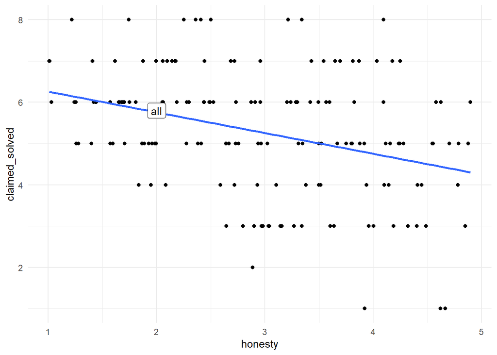

```r
data %>%
ggplot(aes(x = honesty, y = claimed_solved)) +
  geom_point()+
  geom_smooth(method = "lm", se = FALSE)+
  geom_label(x = 2, y = 5.8, label = "all") +
  theme_minimal()
```

Second, let’s perform a simple regression model using `honesty` as a single predictor of number of problems people claimed they solved, `claimed_solved`.

$$\hat{Claimed_i} = \beta_0 +
\beta_1Honesty$$

Run this model using `lm()`.

```r
# your code here
model_simple <- lm(claimed_solved ~ honesty, data = data)
summary(model_simple)
```

```
##
## Call:
## lm(formula = claimed_solved ~ honesty, data = data)
##
## Residuals:
##     Min      1Q  Median      3Q     Max
## -3.7943 -0.9189  0.0864  0.8906  3.2935
##
## Coefficients:
##             Estimate Std. Error t value             Pr(>|t|)
## (Intercept)   6.7614     0.3334  20.282 < 0.0000000000000002 ***
## honesty      -0.5019     0.1067  -4.706            0.0000054 ***
## ---
## Signif. codes:  0 '***' 0.001 '**' 0.01 '*' 0.05 '.' 0.1 ' ' 1
##
## Residual standard error: 1.408 on 162 degrees of freedom
## Multiple R-squared:  0.1202, Adjusted R-squared:  0.1148
## F-statistic: 22.14 on 1 and 162 DF,  p-value: 0.000005396
```

> Question: Write the full model with parameter estimates filled in:

$$\hat{Claimed_i} = 6.76 -0.50Honesty$$

> Question: What do each of the parameter estimates mean?

b0: 6.76, predicted number of problems people claim to have solved when honesty = 0

b1: -0.50, for every 1-unit increase in honesty, the model predicts a decrease of 0.50 in number of problems people claim to have solved

# Main Effects of Categorical & Continuous Variables

Let’s look at a model that investigates both `honesty` and `condition` as predictors of `claimed_solved`, but not their interaction.

$$\hat{Claimed_i} = \beta_0 +
\beta_1Honesty + \beta_2Condition$$

Run this model using `lm()`.

```r
# your code here
model_main_effects <- lm(claimed_solved ~ honesty + condition, data = data)
summary(model_main_effects)
```

```
##
## Call:
## lm(formula = claimed_solved ~ honesty + condition, data = data)
##
## Residuals:
##     Min      1Q  Median      3Q     Max
## -3.2772 -0.8752 -0.0496  0.8876  3.0237
##
## Coefficients:
##                   Estimate Std. Error t value             Pr(>|t|)
## (Intercept)        6.03706    0.33345  18.105 < 0.0000000000000002 ***
## honesty           -0.44900    0.09856  -4.556          0.000010263 ***
## conditionShredder  1.12294    0.20322   5.526          0.000000129 ***
## ---
## Signif. codes:  0 '***' 0.001 '**' 0.01 '*' 0.05 '.' 0.1 ' ' 1
##
## Residual standard error: 1.295 on 161 degrees of freedom
## Multiple R-squared:  0.2605, Adjusted R-squared:  0.2513
## F-statistic: 28.36 on 2 and 161 DF,  p-value: 0.00000000002816
```

> Question: Write the full model with parameter estimates filled in:

$$\hat{Claimed_i} = 6.04 -0.45Honesty +
1.12Condition$$

> Question: What do each of the parameter estimates mean?

b0: 6.04, predicted number of problems people claim to have solved when honesty = 0 and condition = 0 (non-shredder condition)

We could simplify the above equation to represent the relationship between honesty and number of problems people claim to have solved for the non-shredder (condition = 0) and shredder conditions (condition = 1):

- Non-shredder (Condition = 0):

$$\hat{Claimed_i} = 6.04 -0.45Honesty +
1.12(0) = 6.04 - 0.45Honesty$$
* Shredder (Condition = 1):

$$\hat{Claimed_i} = 6.04 -0.45Honesty +
1.12(1) = 7.16 - 0.45Honesty$$
Notice that the only difference between these two equations are their intercepts. If we graphed the two models, it would look like:

[figure not shown]

```r
data %>%
ggplot(aes(x = honesty, y = claimed_solved)) +
  geom_point() +
  geom_abline(slope = -.45, intercept = 6.04, color = "red", size = 1) +
  geom_abline(slope = -.45, intercept = 7.16, color = "blue", size = 1) +
  geom_label(x = 1.5, y = 5.2, label = "shredder") +
  geom_label(x = 1.5, y =6.5, label = "no shredder") +
  theme_minimal()
```

We are not allowing the relationship between `honesty` and `claimed_solved` to differ between the two *shredder* and *non-shredder* conditions.

However, our theory predicts that people will act differently depending on the condition that they were in. To investigate this, we need to include the *interaction effect* to examine whether the relationship between honesty and number of problems people claimed they solves *differs depending on whether people were in the non-shredder or shredder condition*.

# Continuous x Categorical Interaction

## Visualization

First, let’s graph the continuous X categorical interaction between honesty and condition.

In `ggplot`:

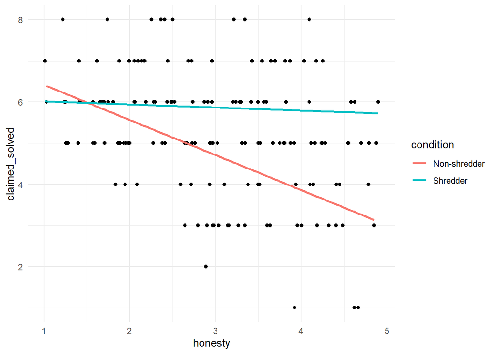

```r
# on a single graph
data %>%
ggplot(aes(x = honesty, y = claimed_solved)) +
  geom_point()+
  geom_smooth(method = "lm", se = FALSE, aes(color = condition)) +
  # scale_color_manual(values = c("red", "blue")) +
  theme_minimal()
```

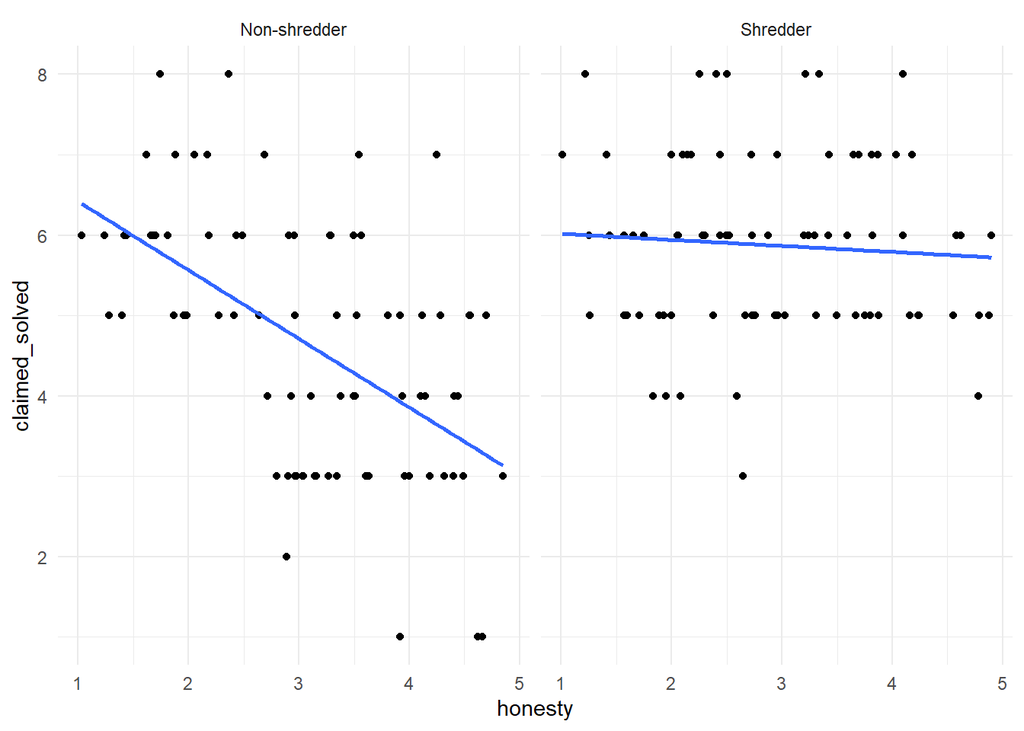

```r
# on two separate graphs
data %>%
ggplot(aes(x = honesty, y = claimed_solved)) +
  geom_point()+
  geom_smooth(method = "lm", se = FALSE)+
  facet_wrap(~condition) +
  theme_minimal()
```

It certainly looks like there could be a significant interaction effect. Let’s run the multiple regression model to examine it further.

## Centering

Notice that in this case, honesty has been measured on a 1 to 5 scale. If we do *not* center honesty first, the model intercept will correspond to the predicted `claimed_solved` score when honesty = 0, a value that falls outside of the range of possible ones.

Typically, the continuous variables will be centered prior to running the analysis. This guarantees that the intercept will intersect the y-axis at a meaningful value (when the predictor is equal to its mean).

To center the continuous predictor:

```r
# You can either...
data <- data %>%
   mutate(honesty_c = honesty - mean(honesty), # subtract the mean, or
          honesty_center = scale(honesty, scale = FALSE)) # use the scale() function
```

## Running the Interaction Model

Run a multiple regression model predicting `claimed_solved` from `honest_c`, `condition`, and the interaction between the two.

```r
# Your code here
model_int <- lm(claimed_solved ~ honesty_c*condition, data = data)
summary(model_int)
```

```
##
## Call:
## lm(formula = claimed_solved ~ honesty_c * condition, data = data)
##
## Residuals:
##     Min      1Q  Median      3Q     Max
## -2.9265 -0.8677  0.0491  1.0581  3.3533
##
## Coefficients:
##                             Estimate Std. Error t value             Pr(>|t|)
## (Intercept)                   4.7531     0.1379  34.476 < 0.0000000000000002
## honesty_c                    -0.8532     0.1356  -6.294        0.00000000284
## conditionShredder             1.1190     0.1938   5.775        0.00000003894
## honesty_c:conditionShredder   0.7781     0.1881   4.137        0.00005660703
##
## (Intercept)                 ***
## honesty_c                   ***
## conditionShredder           ***
## honesty_c:conditionShredder ***
## ---
## Signif. codes:  0 '***' 0.001 '**' 0.01 '*' 0.05 '.' 0.1 ' ' 1
##
## Residual standard error: 1.235 on 160 degrees of freedom
## Multiple R-squared:  0.332,  Adjusted R-squared:  0.3194
## F-statistic:  26.5 on 3 and 160 DF,  p-value: 0.00000000000005695
```

One more way of plotting the interaction after you’ve run the interaction model:

In `sjPlot`

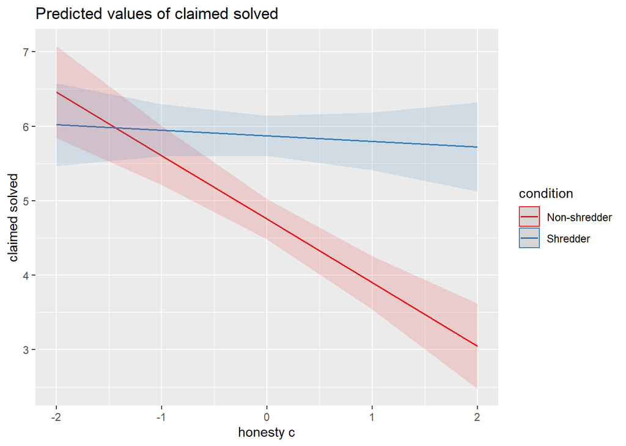

```r
plot_model(model_int, type = "pred", terms = c("honesty_c", "condition")) # type = "pred" means a plot of the predictor vs the predicted values of y
```

```r
# the first variable listed in the terms goes on the x-axis, the second variable gets its levels separated by color
```

> Question: Write the full model with parameter estimates filled in:

$$\hat{Claimed_i} = 4.75 -0.85Honesty_C +
1.12Condition + 0.78Honest_C*Condition$$

> Question: What do each of the parameter estimates mean?

b0: 4.75, the predicted `claimed_solved` for someone with a mean honesty score (honesty_c = 0) and in the non-shredder condition (non-shredder = 0)

b1: -0.85, for every 1-unit increase in honesty_c, the model predicts a *decrease* in `claimed_solved` of 0.85 while controlling for `condition` (when condition = 0, which is the non-shredder condition)

b2: 1.12, the difference in `claimed_solved` between the non-shredder and shredder conditions while controlling for `honesty_c` (when honesty_c = 0, which is the mean of honesty)

Claimed = 4.75 -0.85Honesty_c + 1.12Condition + 0.78(Honesty_c X Condition)

Mean_Non-shredder: 4.75 - 0.85(0) + 1.12(0) + 0.78(0x0) = 4.75 Mean_Shredder: 4.75 -0.85(0) + 1.12(1) + 0.78(0x1) = 5.87

These are called *adjusted means*. Another way of obtaining these adjusted means is by ussing the `emmeans` function:

```r
marg_means <- emmeans(model_int, "condition", by = "honesty_c")
marg_means
```

```
## honesty_c = 0.00000000000000022:
##  condition    emmean    SE  df lower.CL upper.CL
##  Non-shredder   4.75 0.138 160     4.48     5.03
##  Shredder       5.87 0.136 160     5.60     6.14
##
## Confidence level used: 0.95
```

b3: 0.78, the change in the slope representing the relationship between `honesty_c` and `claimed_solved` between the *non-shredder* condition and the *shredder* condition (aka, the change in the simple slopes)

The *simple slopes* are the slopes representing the relationship between predictor 1 and Y at specific levels of predictor 2. We can get simple slopes to examine what the relationship is between `honesty_c` and `claimed_solved` at different levels of `condition`.

## Testing Significance of Simple Slopes

To get the *simple slopes* we can use the `emtrends` function from the `emmeans` package.

There are different questions we can ask by calculating simple slopes and performing hypothesis tests with them.

Q1: Is honesty a significant predictor of number of problems people claim to have solved at each level of condition (non-shredder & shredder conditions)?

```r
emtrends(model_int, ~condition, var = "honesty_c")
```

```
##  condition    honesty_c.trend    SE  df lower.CL upper.CL
##  Non-shredder         -0.8532 0.136 160   -1.121   -0.586
##  Shredder             -0.0751 0.130 160   -0.333    0.182
##
## Confidence level used: 0.95
```

Q2: Is the slope for the non-shredder condition (-0.85) significantly different from the slope for the shredder condition (-0.08)?

```r
emtrends(model_int, pairwise~condition, var = "honesty_c")
```

```
## $emtrends
##  condition    honesty_c.trend    SE  df lower.CL upper.CL
##  Non-shredder         -0.8532 0.136 160   -1.121   -0.586
##  Shredder             -0.0751 0.130 160   -0.333    0.182
##
## Confidence level used: 0.95
##
## $contrasts
##  contrast                  estimate    SE  df t.ratio p.value
##  (Non-shredder) - Shredder   -0.778 0.188 160  -4.137  0.0001
```

This is the same as the test of the interaction effect from the overall model.

Q3: Is there a significant difference in the number of problems people claimed to have solved between the non-shredder and shredder conditions at different levels of honesty?

Because honesty is a continuous variable, we first have to choose specific values to examine the difference between non-shredder and shredder conditions at.

```r
chosen_values <- list(honesty_c=c(-2, -1, 0, 1, 2), condition = c("Non-shredder","Shredder"))

combinations <- emmeans(model_int, ~ honesty_c*condition, at=chosen_values)

#from emmeans
contrast(combinations, "pairwise", by = "honesty_c")
```

```
## honesty_c = -2:
##  contrast                  estimate    SE  df t.ratio p.value
##  (Non-shredder) - Shredder    0.437 0.424 160   1.032  0.3038
##
## honesty_c = -1:
##  contrast                  estimate    SE  df t.ratio p.value
##  (Non-shredder) - Shredder   -0.341 0.271 160  -1.259  0.2099
##
## honesty_c =  0:
##  contrast                  estimate    SE  df t.ratio p.value
##  (Non-shredder) - Shredder   -1.119 0.194 160  -5.775  <.0001
##
## honesty_c =  1:
##  contrast                  estimate    SE  df t.ratio p.value
##  (Non-shredder) - Shredder   -1.897 0.269 160  -7.043  <.0001
##
## honesty_c =  2:
##  contrast                  estimate    SE  df t.ratio p.value
##  (Non-shredder) - Shredder   -2.675 0.422 160  -6.336  <.0001
```

# Minihacks

You are interested in whether the time students spend studying (`study_time`) interacts with test anxiety (`anxiety`) to predict students’ test performance (`perf`).

Import the data below:

```r
test_perf <- import("https://raw.githubusercontent.com/uopsych/psy612/master/labs/lab-7/data/test_perf.csv")
```

```r
head(test_perf)
```

|  | perf | anxiety | study_time |
| --- | --- | --- | --- |
| 1 | 60 | low | 1.35 |
| 2 | 60 | low | 1.80 |
| 3 | 65 | low | 1.80 |
| 4 | 65 | low | 1.80 |
| 5 | 70 | low | 2.25 |
| 6 | 85 | low | 2.25 |

```r
str(test_perf)
```

```
## 'data.frame':    73 obs. of  3 variables:
##  $ perf      : int  60 60 65 65 70 85 70 75 75 75 ...
##  $ anxiety   : chr  "low" "low" "low" "low" ...
##  $ study_time: num  1.35 1.8 1.8 1.8 2.25 2.25 2.7 2.7 3.15 3.15 ...
```

```r
psych::describe(test_perf)
```

|  | vars | n | mean | sd | median | trimmed | mad | min | max | range | skew | kurtosis | se |
| --- | --- | --- | --- | --- | --- | --- | --- | --- | --- | --- | --- | --- | --- |
| perf | 1 | 73 | 77.397260 | 11.0588573 | 75.0 | 77.118644 | 14.82600 | 55.0 | 100.0 | 45.0 | 0.16754837 | -0.7140066 | 1.29434135 |
| anxiety* | 2 | 73 | 1.616438 | 0.4896182 | 2.0 | 1.644068 | 0.00000 | 1.0 | 2.0 | 1.0 | -0.46911369 | -1.8040855 | 0.05730548 |
| study_time | 3 | 73 | 3.550685 | 1.4878791 | 3.6 | 3.561864 | 2.00151 | 0.9 | 6.3 | 5.4 | -0.02543826 | -1.1631335 | 0.17414308 |

As you can see, anxiety is measured categorically (“low” or “high”) and study time ranges from .9 hours to 6.30 hours.

## Minihack 1

Run a model testing whether test anxiety moderates the relationship between time spent studying and test performance. Center study time so that it is more meaningful.

```r
test_perf <- test_perf %>%
  mutate(anxiety = factor(anxiety,
                          levels= c("low", "high")),
         study_time_c = scale(study_time, scale = FALSE))

model <- lm(data= test_perf, perf ~ anxiety*study_time_c)
summary(model)
```

```
##
## Call:
## lm(formula = perf ~ anxiety * study_time_c, data = test_perf)
##
## Residuals:
##      Min       1Q   Median       3Q      Max
## -17.5858  -2.2278  -0.7574   1.0058  17.9678
##
## Coefficients:
##                          Estimate Std. Error t value             Pr(>|t|)
## (Intercept)               79.4890     0.8682  91.552 < 0.0000000000000002 ***
## anxietyhigh               -6.2434     1.4033  -4.449        0.00003226284 ***
## study_time_c               7.8435     0.6197  12.657 < 0.0000000000000002 ***
## anxietyhigh:study_time_c  -6.1967     0.9290  -6.671        0.00000000523 ***
## ---
## Signif. codes:  0 '***' 0.001 '**' 0.01 '*' 0.05 '.' 0.1 ' ' 1
##
## Residual standard error: 5.815 on 69 degrees of freedom
## Multiple R-squared:  0.735,  Adjusted R-squared:  0.7235
## F-statistic:  63.8 on 3 and 69 DF,  p-value: < 0.00000000000000022
```

Interpret the model coefficients.

## Minihack 2

Visualize the interaction using `sjPlot` or `ggplot`.

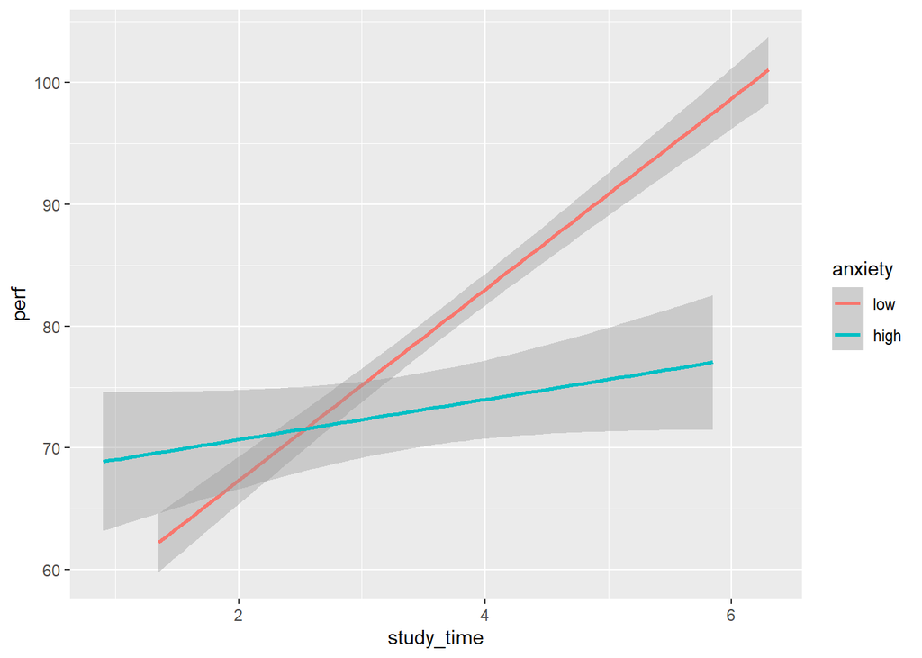

```r
test_perf %>%
ggplot(aes(x= study_time, y = perf, color = anxiety)) +
  geom_smooth(method = "lm")
```

## Minihack 3

Test whether each simple slope is significantly different from 0.

```r
emtrends(model, ~anxiety, var = "study_time_c")
```

```
##  anxiety study_time_c.trend    SE df lower.CL upper.CL
##  low                   7.84 0.620 69    6.607     9.08
##  high                  1.65 0.692 69    0.266     3.03
##
## Confidence level used: 0.95
```

Test whether the simple slopes for low anxiety and high anxiety are significantly different from each other.

```r
emtrends(model, pairwise~anxiety, var = "study_time_c")
```

```
## $emtrends
##  anxiety study_time_c.trend    SE df lower.CL upper.CL
##  low                   7.84 0.620 69    6.607     9.08
##  high                  1.65 0.692 69    0.266     3.03
##
## Confidence level used: 0.95
##
## $contrasts
##  contrast   estimate    SE df t.ratio p.value
##  low - high      6.2 0.929 69   6.671  <.0001
```

What do the results of these significance tests mean?

1. Since 0 isn’t in the confidence intervals, both of these slopes are significantly greater than 0. This means that the relation between study time and performance is significant at both high and low anxiety.
2. Since p < .001, the slope for the low anxiety condition is significantly greater than the slope for the high anxiety condition.